# Pipeline FDA: Analisi Funzionale Alto Adriatico

Leo

2025-12-02

# 1 Introduzione

**Scopo dell’analisi:** Trasformare dati spaziali/temporali discreti (punti nel tempo) in curve funzionali continue per analizzarne la varianza tramite Functional PCA (FPCA). **Dataset:** Dati Copernicus Marine (Clorofilla, Temperatura, Salinità) per l’Alto Adriatico.

# 2 Setup e Librerie

Carichiamo le librerie necessarie per la manipolazione dati (`tidyverse`), l’analisi funzionale (`fda`) e la visualizzazione spaziale (`maps`, `fields`).

```r
library(tidyverse)
library(lubridate)
library(data.table)
library(fda)        # Analisi Funzionale
library(maps)       # Per i confini geografici
library(fields)     # Utilità grafiche spaziali
```

# 3 Caricamento e Pre-processing

In questa fase importiamo il dataset “mergiato”, convertiamo le date nel formato corretto e ci assicuriamo che l’ordinamento sia coerente (Latitudine, Longitudine, Data) per le fasi successive.

```r
# Imposta il percorso del file
path <- "/Users/leomarcellopoli/Documents/Nonparametric/Project/Non-parametric-Statistics-2025-2026/dataset/dataset_MERGIATO"

# Lettura del CSV
df <- read.csv(path, stringsAsFactors = FALSE)

# Pre-processing:
# 1. Conversione Data
# 2. Ordinamento (Fondamentale per la struttura a matrice)
df <- df %>%
  mutate(Date = as.Date(Date)) %>%
  arrange(Lon, Lat, Date)

# Gestione ID Stazioni spaziali
setDT(df)
locations <- unique(df[, .(Lon, Lat)])
locations$loc_id <- seq_len(nrow(locations))

# Join per assegnare loc_id al dataset principale
df <- df %>% left_join(locations, by = c("Lon","Lat"))

# Info Dataset
cat("Righe totali:", nrow(df), "\n")
```

```
## Righe totali: 481290
```

```r
cat("Stazioni uniche:", nrow(locations), "\n")
```

```
## Stazioni uniche: 1315
```

```r
cat("Giorni totali:", length(unique(df$Date)), "\n")
```

```
## Giorni totali: 366
```

# 4 Trasformazione in Matrici (Data-Matrix)

La libreria `fda` richiede i dati in formato matrice (Stazioni x Tempo), non in formato “Tidy”. Qui eseguiamo la conversione per le variabili di interesse.

```r
# Definiamo l'asse temporale completo
dates <- sort(unique(df$Date))
T_len <- length(dates)
time_seq <- 1:T_len

# Funzione personalizzata per trasformare il dataset in matrice
make_matrix <- function(varname){
  m <- matrix(NA, nrow = nrow(locations), ncol = T_len)
  colnames(m) <- as.character(dates)

  for(i in seq_len(nrow(locations))){
    tmp <- df %>% filter(loc_id == i) %>% arrange(Date)
    if(nrow(tmp) > 0){
      idx <- match(as.character(tmp$Date), colnames(m))
      m[i, idx] <- tmp[[varname]]
    }
  }
  return(m)
}

# Creazione Matrici
chl_mat  <- make_matrix("Chl")
temp_mat <- make_matrix("Temp")
sal_mat  <- make_matrix("Salinity")
# solar_mat <- make_matrix("Solar_Flux")
```

# 5 Esplorazione Grafica

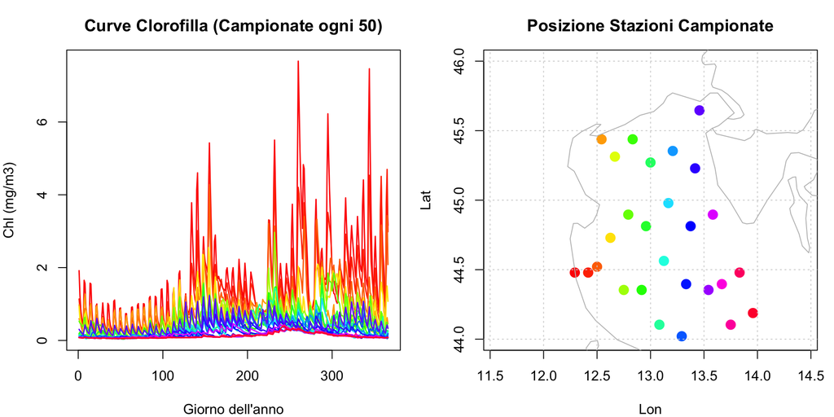

```r
# 1. Definiamo gli indici da prendere (Campionamento sistematico)
# seq(da, a, passo): Prende la riga 1, la 51, la 101, ecc. fino alla fine
idx_plot <- seq(1, nrow(locations), by = 50)

# Calcoliamo quante stazioni stiamo plottando (saranno circa 26-27 su 1315)
n_plot <- length(idx_plot)

# 2. Estraiamo le coordinate di queste specifiche stazioni
loc_plot <- locations[idx_plot, ]

# Setup Layout affiancato
par(mfrow = c(1, 2), mar = c(4, 4, 3, 1))

# A. Spaghetti Plot (Sinistra)
# ATTENZIONE: Qui usiamo [, idx_plot] invece di [, 1:n_plot]
# perché dobbiamo pescare le colonne specifiche corrispondenti agli indici scelti
matplot(time_seq, t(chl_mat)[, idx_plot],
        type = 'l', lty = 1, lwd = 1.5, col = rainbow(n_plot),
        main = paste("Curve Clorofilla (Campionate ogni 50)"),
        xlab = "Giorno dell'anno", ylab = "Chl (mg/m3)")

# B. Mappa Stazioni (Destra)
plot(loc_plot$Lon, loc_plot$Lat,
     pch = 19, cex = 1.5, col = rainbow(n_plot),
     xlim = c(12, 14), ylim = c(44, 46), asp = 1.3,
     xlab = "Lon", ylab = "Lat", main = "Posizione Stazioni Campionate")
map('world', add = TRUE, col = "gray")
grid()
```

```r
# Reset layout
par(mfrow = c(1, 1))
```

# 6 Smoothing Funzionale (B-Splines)

Trasformiamo i dati discreti in funzioni continue $x(t)$ utilizzando una base di B-Splines. Abbiamo scelto **35 basi** come compromesso tra il fitting dei dati e la rimozione del rumore (smoothing).

```r
nbasis <- 35
basis  <- create.bspline.basis(rangeval = c(1, T_len), nbasis = nbasis)

cat("Esecuzione Smoothing...\n")
```

```
## Esecuzione Smoothing...
```

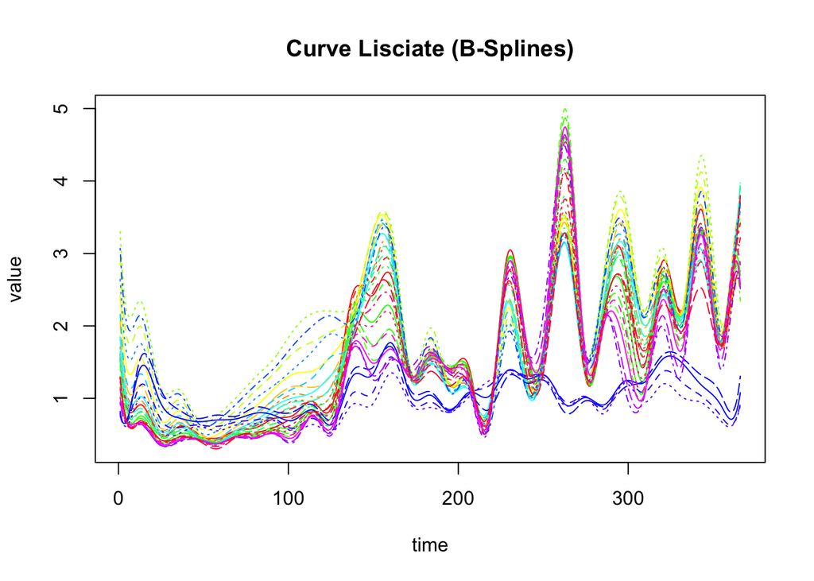

```
## [1] "done"
```

```r
chl_fd  <- Data2fd(y = t(chl_mat), argvals = time_seq, basisobj = basis)
temp_fd <- Data2fd(y = t(temp_mat), argvals = time_seq, basisobj = basis)
sal_fd  <- Data2fd(y = t(sal_mat), argvals = time_seq, basisobj = basis)

# Verifica visiva
plot(chl_fd[1:30], main = "Curve Lisciate (B-Splines)", col=rainbow(30))
```

# 7 Functional PCA (FPCA)

Analizziamo i modi principali di variazione delle curve di clorofilla attraverso l’Analisi delle Componenti Principali Funzionali.

```r
nharm <- 6
chl_fpca <- pca.fd(chl_fd, nharm = nharm, centerfns = TRUE)
```

## 7.1 Scree Plot: Varianza Spiegata

Verifichiamo quante componenti sono necessarie per spiegare la maggior parte della variabilità (target > 90%).

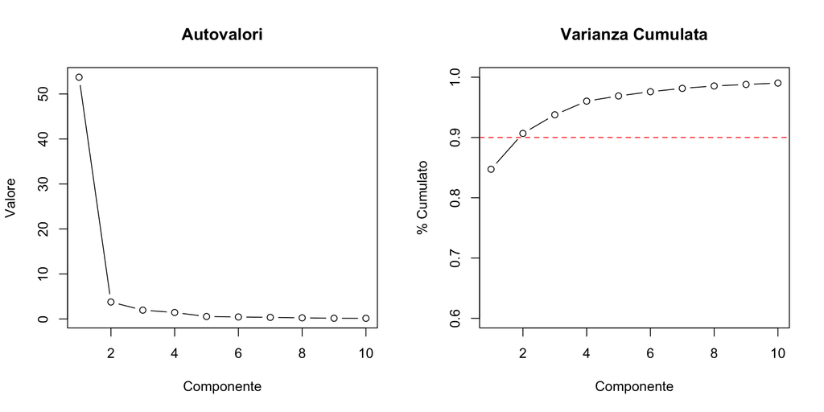

```r
par(mfrow=c(1,2))

# Grafico degli autovalori
plot(chl_fpca$values[1:10], type='b', main="Autovalori", xlab="Componente", ylab="Valore")

# Grafico varianza cumulata
plot(cumsum(chl_fpca$values)[1:10]/sum(chl_fpca$values), type='b',
     ylim=c(0.6, 1), main="Varianza Cumulata", xlab="Componente", ylab="% Cumulato")
abline(h=0.9, col="red", lty=2)
```

```r
par(mfrow=c(1,1))
```

## 7.2 Interpretazione delle Armoniche

Visualizziamo la forma delle prime 3 autofunzioni (Eigenfunctions) per interpretare i pattern temporali.

```r
par(mfrow = c(1,3))
plot(chl_fpca$harmonics[1,], col=1, ylab='FPC1', main="1° Modo Variazione")
```

```
## [1] "done"
```

```r
abline(h=0, lty=2)
plot(chl_fpca$harmonics[2,], col=2, ylab='FPC2', main="2° Modo Variazione")
```

```
## [1] "done"
```

```r
abline(h=0, lty=2)
plot(chl_fpca$harmonics[3,], col=3, ylab='FPC3', main="3° Modo Variazione")
```

```
## [1] "done"
```

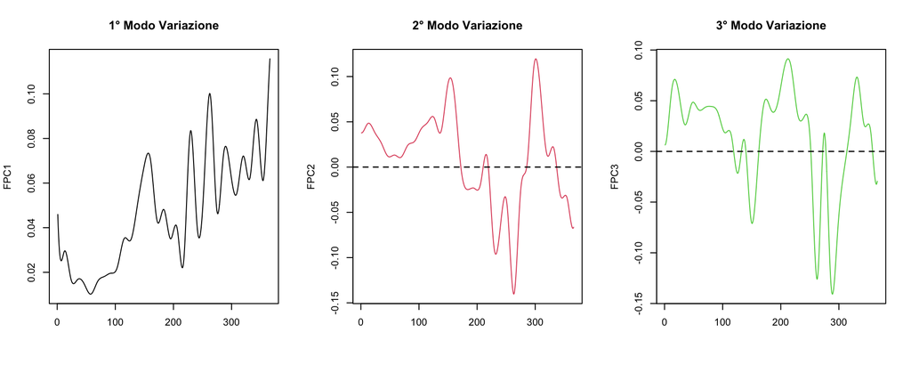

```r
abline(h=0, lty=2)
```

```r
par(mfrow=c(1,1))
```

## 7.3 Perturbation Plot

Questo grafico mostra come la media globale (linea continua) viene modificata aggiungendo (+) o sottraendo (-) una deviazione standard lungo ciascuna componente principale. Aiuta a visualizzare l’effetto fisico della componente.

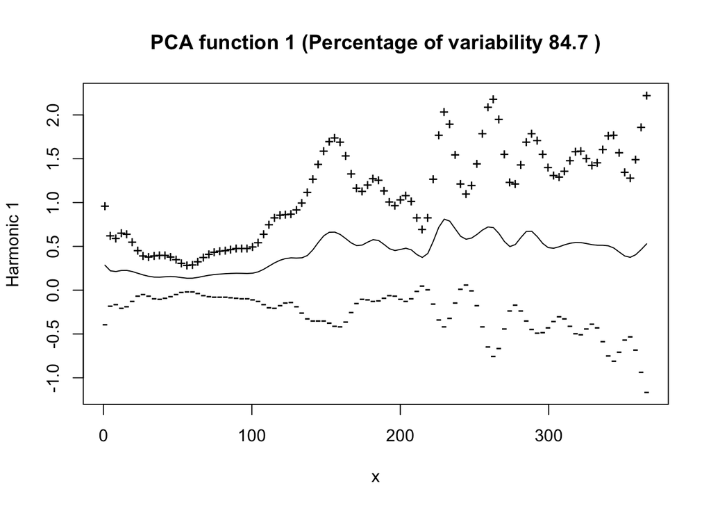

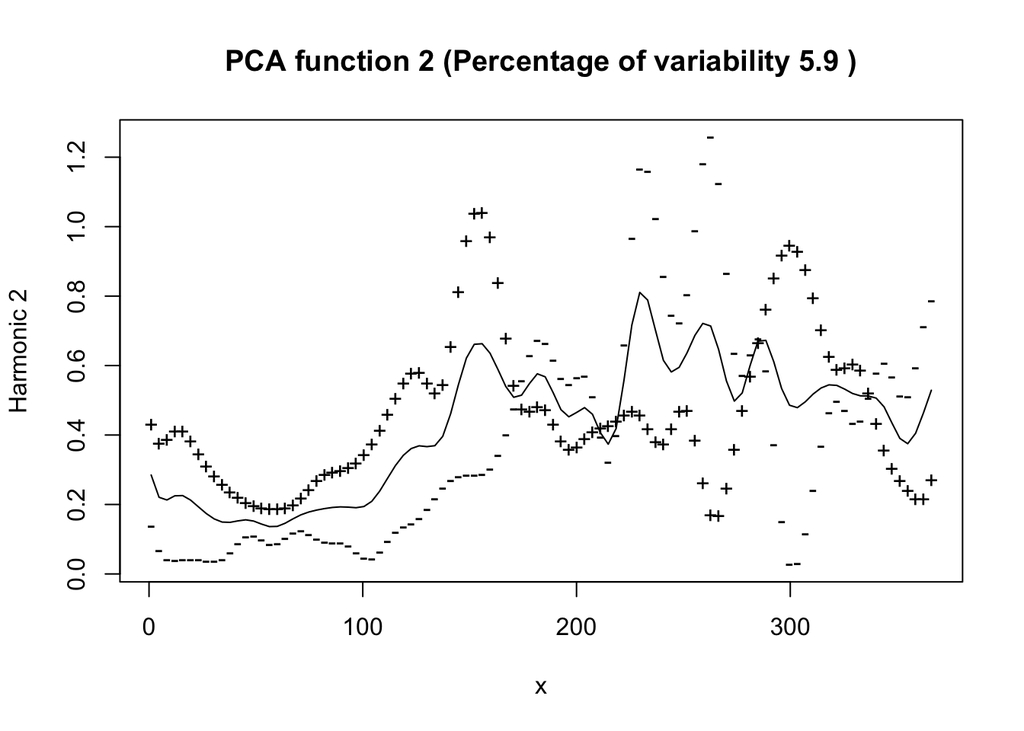

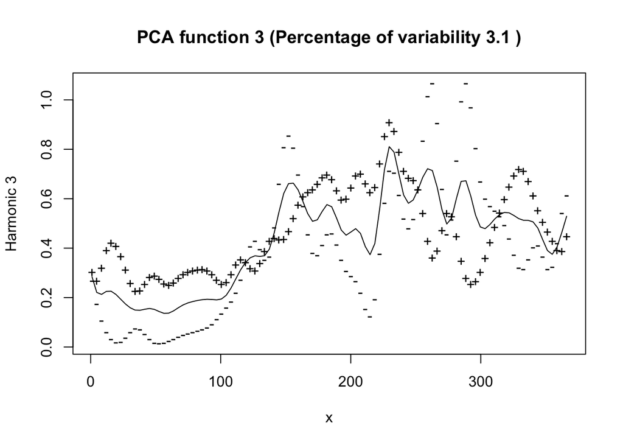

```r
plot.pca.fd(chl_fpca, nx=100, pointplot=TRUE, harm=c(1,2,3), expand=0, cycle=FALSE)
```

```r
cat("Analisi Completata.")
```

```
## Analisi Completata.
```